# Modeling

```r
library(dplyr)
library(kableExtra)
library(caret)
library(doParallel)
```

We tune a total of 6 models from the following categories of models:

- Linear models: partial least square, elastic nets
- Non-linear models: k-nearest neighbors, support vector machine
- Tree-based models: random forest, gradient boosting machines

## Data Preparation

```r
# Read in data
train <- readxl::read_excel('Data//StudentData.xlsx')
eval <- readxl::read_excel('Data//StudentEvaluation.xlsx')
```

The variable `Brand Code` is a categorical variable, having 4 classes (A, B, C, and D). We opt to use the “one-hot” encoding scheme for this variable, creating 5 new variables for the data: BrandCodeA, BrandCodeB, BrandCodeC, BrandCodeD, and BrandCodeNA.

```r
# One-hot encoding the categorical variable `Brand Code`
train$`Brand Code` <- addNA(train$`Brand Code`)
eval$`Brand Code` <- addNA(eval$`Brand Code`)
brandCodeTrain <- predict(dummyVars(~`Brand Code`, data=train), train)
brandCodeEval <- predict(dummyVars(~`Brand Code`, data=eval), eval)
head(brandCodeTrain, 10)
```

```
##    `Brand Code`A `Brand Code`B `Brand Code`C `Brand Code`D `Brand Code`NA
## 1              0             1             0             0              0
## 2              1             0             0             0              0
## 3              0             1             0             0              0
## 4              1             0             0             0              0
## 5              1             0             0             0              0
## 6              1             0             0             0              0
## 7              1             0             0             0              0
## 8              0             1             0             0              0
## 9              0             1             0             0              0
## 10             0             1             0             0              0
```

```r
head(train$`Brand Code`, 10)
```

```
##  [1] B A B A A A A B B B
## Levels: A B C D <NA>
```

```r
head(brandCodeEval, 10)
```

```
##    `Brand Code`A `Brand Code`B `Brand Code`C `Brand Code`D `Brand Code`NA
## 1              0             0             0             1              0
## 2              1             0             0             0              0
## 3              0             1             0             0              0
## 4              0             1             0             0              0
## 5              0             1             0             0              0
## 6              0             1             0             0              0
## 7              1             0             0             0              0
## 8              0             1             0             0              0
## 9              1             0             0             0              0
## 10             0             0             0             1              0
```

```r
head(eval$`Brand Code`, 10)
```

```
##  [1] D A B B B B A B A D
## Levels: A B C D <NA>
```

```r
train <- cbind(brandCodeTrain, subset(train, select=-c(`Brand Code`)))
eval <- cbind(brandCodeEval, subset(eval, select=-c(`Brand Code`)))
```

White spaces and special characters in the column names are removed so they does not cause issues in some of the R packages.

```r
# Remove special symbols (white space and `) in names
names(train) <- gsub(patter=c(' |`'), replacement='', names(train))
names(eval) <- gsub(patter=c(' |`'), replacement='', names(eval))
```

There are a few rows with target variable (PH) missing. These rows are removed, since they cannot be used for training.

```r
# Remove rows in training set with missing target variables
train <- train[complete.cases(train$PH),]
```

```r
# Check near-zero-variance variables
nearZeroVar(train, names=T)
```

```
## [1] "BrandCodeNA"  "HydPressure1"
```

```r
# Separate the predictors and target, and remove nzv variable
xTrain <- subset(train, select=-c(PH,`HydPressure1`)) %>% as.data.frame()
xEval <- subset(eval, select=-c(PH,`HydPressure1`)) %>% as.data.frame()
yTrain <- train$PH
```

The `train` function from the `caret` package is used to tune the models. The 5-fold cross validation scheme is used to estimate the model performance based on their RMSE. Below, we create the folds and set up the train control:

```r
set.seed(1)
cvFolds <- createFolds(yTrain, k=5)
trControl <- trainControl(verboseIter=T,
                          method='cv',
                          number=5,
                          index=cvFolds)
```

For the missing values, we experiment with three different imputation algorithms provided in the `preProcess` function:

- KNN imputation
- Bagged trees imputation
- Median imputation

As will be seen in the “Linear Models” section below, the choice of imputation method does not seem to affect the prediction performance much. We opt to use the `knnImpute` method due to its high efficiency.

For the linear and non-linear models, the pre-processing step also include centering and scaling (standardizing), so that the variables all have a mean of 0 and standard deviation of 1. For the tree-based models, this step is omitted, since tree models work fine without this step.

The `caret` package supports parallel processing (multi-core training). This capability significantly lowers the training time:

```r
# Set up and start multi-core processing
cl <- makePSOCKcluster(5)
registerDoParallel(cl)
```

## Model Building and Tuning

### Linear Models

In this section, we tune 6 models for the following purpose in mind:

- Understand the effect of different imputation methods on the model performance
- Find the optimal hyper-parameters for the respective linear models

For the partial least squares, the models are tuned over the number of components used in the model. 3 models are created, each uses a different imputation method:

```r
# PLS
plsFit1 <- train(x=xTrain,
                 y=yTrain,
                 method='pls',
                 tuneLength=20,
                 trControl=trControl,
                 preProc=c('knnImpute', 'center', 'scale'))
plsFit2 <- train(x=xTrain,
                 y=yTrain,
                 method='pls',
                 tuneLength=20,
                 trControl=trControl,
                 preProc=c('bagImpute', 'center', 'scale'))
plsFit3 <- train(x=xTrain,
                 y=yTrain,
                 method='pls',
                 tuneLength=20,
                 trControl=trControl,
                 preProc=c('medianImpute', 'center', 'scale'))
```

For the elastic nets, the models are tuned over the two regularization parameters. Likewise, 3 models are tuned, each with different imputation method:

```r
# Elastic Net
enetFit1 <- train(x=xTrain,
                  y=yTrain,
                  method='enet',
                  tuneGrid=expand.grid(.fraction = seq(0, 1, by=0.1),
                                       .lambda = seq(0, 1, by=0.1)),
                  trControl=trControl,
                  preProc=c('knnImpute', 'center', 'scale'))
enetFit2 <- train(x=xTrain,
                  y=yTrain,
                  method='enet',
                  tuneGrid=expand.grid(.fraction = seq(0, 1, by=0.1),
                                       .lambda = seq(0, 1, by=0.1)),
                  trControl=trControl,
                  preProc=c('bagImpute', 'center', 'scale'))
enetFit3 <- train(x=xTrain,
                  y=yTrain,
                  method='enet',
                  tuneGrid=expand.grid(.fraction = seq(0, 1, by=0.1),
                                       .lambda = seq(0, 1, by=0.1)),
                  trControl=trControl,
                  preProc=c('medianImpute', 'center', 'scale'))
```

The performance of these models are be compared using the `resamples` function:

```r
resamples(list(PLS1=plsFit1, PLS2=plsFit2, PLS3=plsFit3,
               enet1=enetFit1, enet2=enetFit2, enet3=enetFit3)) %>% summary()
```

```
##
## Call:
## summary.resamples(object = .)
##
## Models: PLS1, PLS2, PLS3, enet1, enet2, enet3
## Number of resamples: 5
##
## MAE
##            Min.   1st Qu.    Median      Mean   3rd Qu.      Max. NA's
## PLS1  0.1040102 0.1063136 0.1071064 0.1067182 0.1079895 0.1081715    0
## PLS2  0.1046314 0.1060063 0.1075259 0.1069578 0.1078970 0.1087286    0
## PLS3  0.1048040 0.1066420 0.1071693 0.1069891 0.1079980 0.1083322    0
## enet1 0.1032539 0.1056163 0.1070119 0.1061140 0.1071730 0.1075147    0
## enet2 0.1042026 0.1058568 0.1070027 0.1063896 0.1070570 0.1078287    0
## enet3 0.1042282 0.1060427 0.1072512 0.1066468 0.1078112 0.1079009    0
##
## RMSE
##            Min.   1st Qu.    Median      Mean   3rd Qu.      Max. NA's
## PLS1  0.1356567 0.1376909 0.1376948 0.1374621 0.1377316 0.1385362    0
## PLS2  0.1358973 0.1368498 0.1371483 0.1374332 0.1384082 0.1388624    0
## PLS3  0.1363889 0.1377426 0.1379041 0.1378178 0.1384736 0.1385797    0
## enet1 0.1339212 0.1361784 0.1363822 0.1361661 0.1366161 0.1377323    0
## enet2 0.1347075 0.1360830 0.1362463 0.1365080 0.1374337 0.1380693    0
## enet3 0.1348319 0.1363997 0.1368995 0.1368871 0.1369487 0.1393558    0
##
## Rsquared
##            Min.   1st Qu.    Median      Mean   3rd Qu.      Max. NA's
## PLS1  0.3625243 0.3667430 0.3699577 0.3699562 0.3739147 0.3766411    0
## PLS2  0.3648928 0.3649674 0.3664653 0.3685208 0.3728756 0.3734029    0
## PLS3  0.3556132 0.3644181 0.3702737 0.3668091 0.3706663 0.3730739    0
## enet1 0.3700989 0.3727973 0.3781011 0.3778583 0.3811035 0.3871907    0
## enet2 0.3703520 0.3733133 0.3738265 0.3752370 0.3791456 0.3795478    0
## enet3 0.3626465 0.3649488 0.3761665 0.3722877 0.3785394 0.3791373    0
```

As you can see, the performance differences are very small among the different imputation methods. We opt to use the `knnImpute` method from this point on, due to its efficiency.

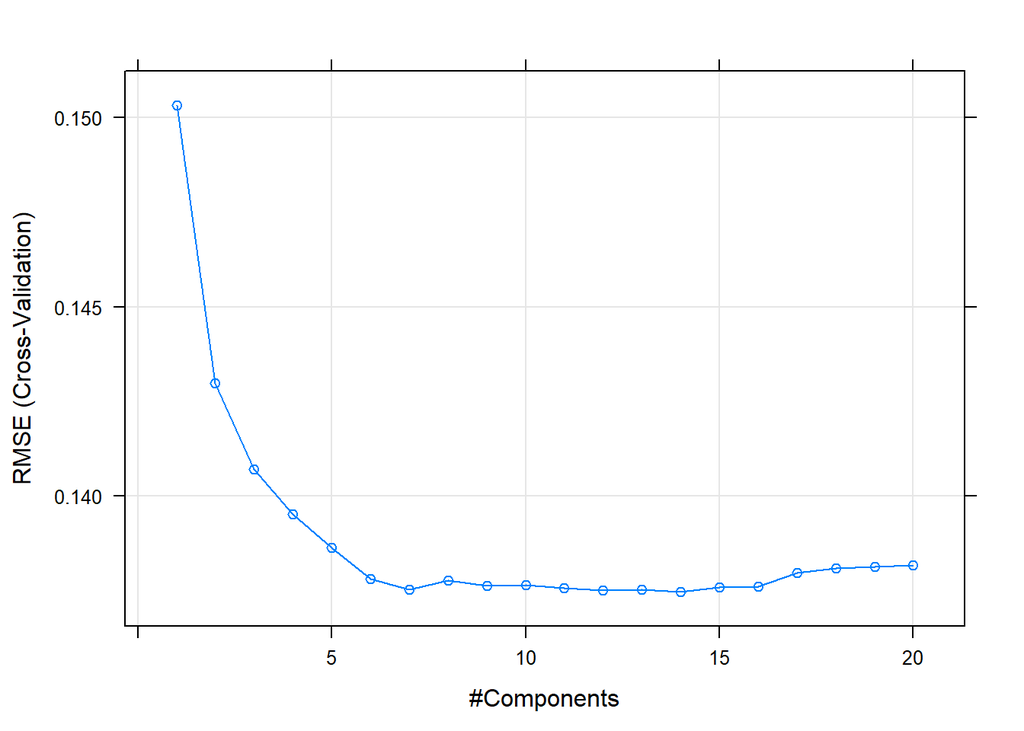

```r
plsFit <- plsFit1
enetFit <- enetFit1

plot(plsFit)
```

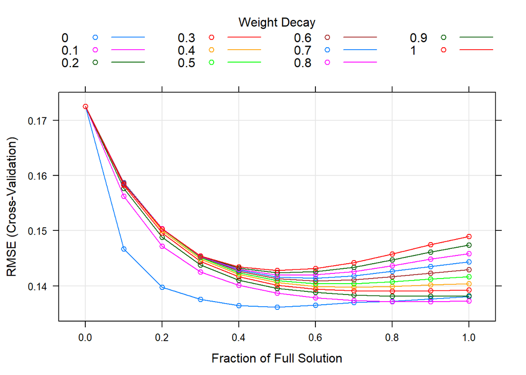

```r
plot(enetFit)
```

The final linear models are:

```r
plsFit$finalModel
```

```
## Partial least squares regression , fitted with the orthogonal scores algorithm.
## Call:
## plsr(formula = .outcome ~ ., ncomp = param$ncomp, data = dat,     method = "oscorespls")
```

```r
enetFit$finalModel
```

```
##
## Call:
## elasticnet::enet(x = as.matrix(x), y = y, lambda = param$lambda)
## Cp statistics of the Lasso fit
## Cp: 1828.781 1300.154 1029.285  836.820  795.467  791.002  790.239  538.139  458.584  439.565  426.175  352.972  305.674  251.236  243.047  208.556  189.786  190.667  171.832  154.297  154.234  153.671  146.067  138.922  107.104  104.545   88.112   84.251   67.606   55.387   56.761   58.066   54.…
## DF:  1  2  3  4  5  6  7  8  9 10 11 12 13 14 15 16 17 18 19 20 21 21 21 22 23 24 25 26 27 28 29 30 31 32 33 34 35 35
## Sequence of  moves:
##      MnfFlow BrandCodeC BowlSetpoint Usagecont PressureSetpoint BrandCodeD
## Var       14          3           30        23               31          4
## Step       1          2            3         4                5          6
##      Temperature BrandCodeA CarbPressure1 BrandCodeNA FillOunces PSC
## Var           22          1            15           5          7  11
## Step           7          8             9          10         11  12
##      HydPressure3 CarbFlow PSCCO2 OxygenFiller PSCFill AlchRel CarbTemp
## Var            18       24     13           29      12      33       10
## Step           13       14     15           16      17      18       19
##      PCVolume MFR BrandCodeD FillPressure Density AirPressurer CarbRel
## Var         8  26         -4           16      25           32      34
## Step       20  21         22           23      24           25      26
##      CarbVolume BallingLvl BrandCodeB PressureVacuum HydPressure2
## Var           6         35          2             28           17
## Step         27         28         29             30           31
##      FillerLevel FillerSpeed Balling HydPressure4 CarbPressure BrandCodeD
## Var           20          21      27           19            9         -4
## Step          32          33      34           35           36         37
##
## Var  38
## Step 38
```

### Non-linear Models

For the KNN method, the model is tuned over the number of k-nearest neighbors used to make prediction:

```r
# KNN
knnFit <- train(x=xTrain,
                y=yTrain,
                method='knn',
                tuneLength=20,
                trControl=trControl,
                preProc=c('knnImpute', 'center', 'scale'))
```

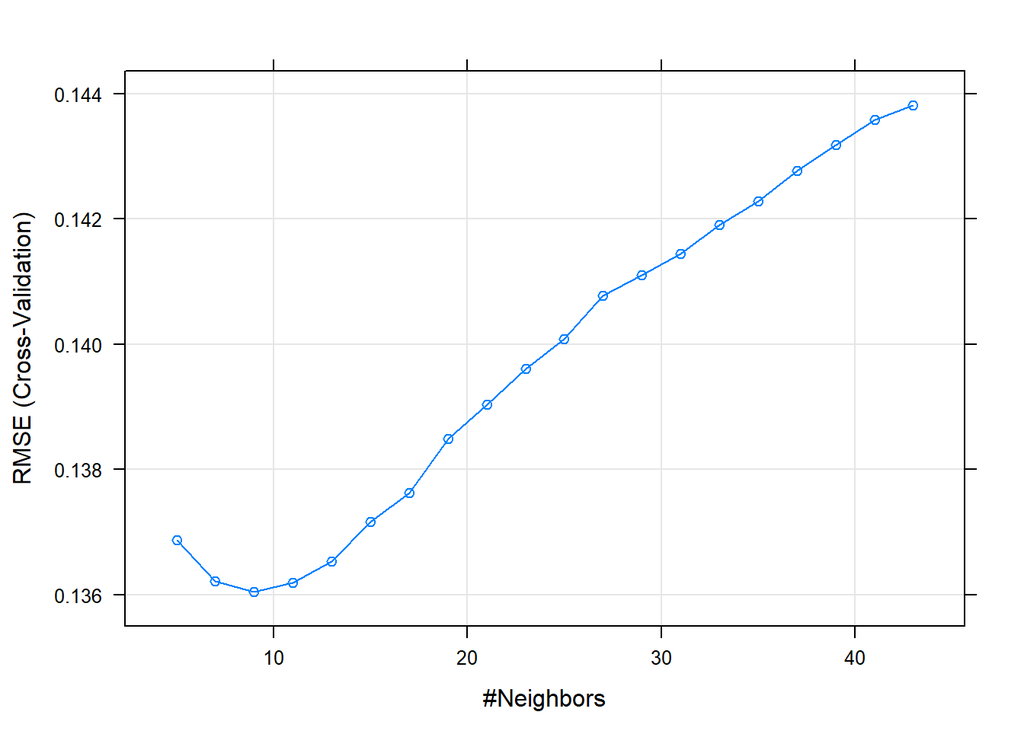

```r
plot(knnFit)
```

For the support vector machine, we choose the radial basis kernel function. The hyper-parameters being tuned is the cost value. The scale parameter sigma is fixed and determined by the function analytically.

```r
# Support Vector Machine
svmFit <- train(x=xTrain,
                y=yTrain,
                method="svmRadial",
                tuneLength=20,
                trControl=trControl,
                preProc=c('knnImpute', 'center', 'scale'))
```

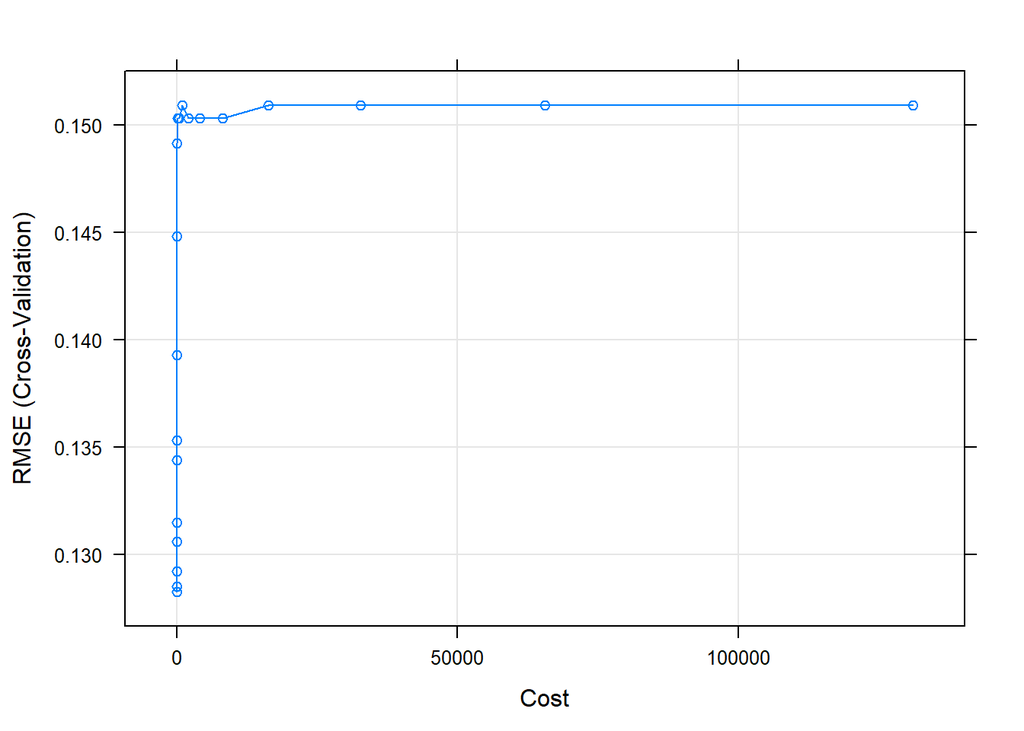

```r
plot(svmFit)
```

The final non-linear models are:

```r
knnFit$finalModel
```

```
## 9-nearest neighbor regression model
```

```r
svmFit$finalModel
```

```
## Support Vector Machine object of class "ksvm"
##
## SV type: eps-svr  (regression)
##  parameter : epsilon = 0.1  cost C = 2
##
## Gaussian Radial Basis kernel function.
##  Hyperparameter : sigma =  0.0201032562509376
##
## Number of Support Vectors : 2175
##
## Objective Function Value : -1643.345
## Training error : 0.271298
```

### Tree-based Models

For the random forest model, the `mtry` parameter, which is the number of randomly selected predictors in each tree, is tuned to obtain the optimal model. The `rf` implementation in R does not permit missing values, therefore `knnImpute` is used in the pre-processing step.

```r
# Random Forest
rf <- train(x=xTrain,
            y=yTrain,
            method='rf',
            tuneLength=10,
            trControl=trControl,
            preProc=c('knnImpute'),
            importance=T)
```

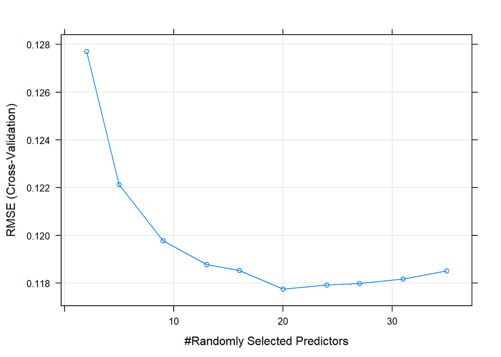

```r
plot(rf)
```

For the XGBoost model, below is a list of the parameters being tuned:

- `nrounds` : boosting iterations (trees)
- `max_depth` : max tree depth
- `eta` : learning rate
- `gamma` : minimum loss reduction
- `colsample_bytree` : subsample ratio of columns
- `min_child_weight` : minimum sum of instance weight
- `subsample` : subsample ratio of rows

In addition, the XGBoost allows missing value in the data. Here, we experiment with both imputing the missing values (with `knnImpute`) and not imputing the missing values.

```r
# XGBoost
xgbGrid <- expand.grid(.nrounds=c(100, 500, 1000, 1500), # boosting iterations (trees)
                       .max_depth=c(4, 6, 8, 10), # max tree depth
                       .eta=c(0.001, 0.01, 0.1, 0.5), # learning rate
                       .gamma=c(0),# minimum loss reduction
                       .colsample_bytree=c(0.4, 0.6, 0.8, 1), # subsample ratio of columns
                       .min_child_weight=c(1, 5, 15), # minimum sum of instance weight
                       .subsample=c(0.5, 0.75, 1))  # subsample ratio of rows

xgb1 <- train(x = xTrain,
              y = yTrain,
              method = 'xgbTree',
              tuneGrid = xgbGrid,
              trControl = trControl)

xgb2 <- train(x = xTrain,
              y = yTrain,
              method = 'xgbTree',
              tuneGrid = xgbGrid,
              trControl = trControl,
              preProce = c('knnImpute'))

# End multi-core processing
stopCluster(cl)
registerDoSEQ()
```

```r
resamples(list(XGB1=xgb1, XGB2=xgb2)) %>% summary()
```

```
##
## Call:
## summary.resamples(object = .)
##
## Models: XGB1, XGB2
## Number of resamples: 5
##
## MAE
##            Min.    1st Qu.     Median       Mean    3rd Qu.       Max.
## XGB1 0.08727048 0.08757008 0.08768184 0.08783904 0.08788029 0.08879249
## XGB2 0.08697277 0.08718546 0.08743389 0.08767905 0.08782876 0.08897435
##      NA's
## XGB1    0
## XGB2    0
##
## RMSE
##           Min.   1st Qu.    Median      Mean   3rd Qu.      Max. NA's
## XGB1 0.1154879 0.1161752 0.1165290 0.1171056 0.1181344 0.1192014    0
## XGB2 0.1156593 0.1157656 0.1164978 0.1170502 0.1180158 0.1193124    0
##
## Rsquared
##           Min.   1st Qu.    Median      Mean   3rd Qu.      Max. NA's
## XGB1 0.5285509 0.5346482 0.5357232 0.5414750 0.5503459 0.5581067    0
## XGB2 0.5281014 0.5351413 0.5416740 0.5423755 0.5419176 0.5650431    0
```

It appears that the performance difference between imputing and not imputing are negligible. We opt to use the imputed model since it is a slight improvement and `knnImpute` does not take that much time to perform.

The final tree-based models are:

```r
rf
```

```
## Random Forest
##
## 2567 samples
##   35 predictor
##
## Pre-processing: nearest neighbor imputation (35), centered (35),
##  scaled (35)
## Resampling: Cross-Validated (5 fold)
## Summary of sample sizes: 514, 514, 513, 513, 513
## Resampling results across tuning parameters:
##
##   mtry  RMSE       Rsquared   MAE
##    2    0.1277131  0.4988421  0.09870782
##    5    0.1221249  0.5299636  0.09319066
##    9    0.1197881  0.5399403  0.09071346
##   13    0.1187889  0.5436157  0.08960861
##   16    0.1185293  0.5426875  0.08926884
##   20    0.1177503  0.5458798  0.08871182
##   24    0.1179296  0.5439091  0.08855143
##   27    0.1179859  0.5399440  0.08836967
##   31    0.1181714  0.5364060  0.08827614
##   35    0.1185114  0.5311831  0.08879924
##
## RMSE was used to select the optimal model using the smallest value.
## The final value used for the model was mtry = 20.
```

```r
xgb <- xgb2
xgb$finalModel
```

```
## ##### xgb.Booster
## Handle is invalid! Suggest using xgb.Booster.complete
## raw: 6.6 Mb
## call:
##   xgboost::xgb.train(params = list(eta = param$eta, max_depth = param$max_depth,
##     gamma = param$gamma, colsample_bytree = param$colsample_bytree,
##     min_child_weight = param$min_child_weight, subsample = param$subsample),
##     data = x, nrounds = param$nrounds, objective = "reg:linear")
## params (as set within xgb.train):
##   eta = "0.01", max_depth = "10", gamma = "0", colsample_bytree = "0.6", min_child_weight = "5", subsample = "1", objective = "reg:linear", silent = "1"
## callbacks:
##   cb.print.evaluation(period = print_every_n)
## # of features: 35
## niter: 1500
## nfeatures : 35
## xNames : BrandCodeA BrandCodeB BrandCodeC BrandCodeD BrandCodeNA CarbVolume FillOunces PCVolume CarbPressure CarbTemp PSC PSCFill PSCCO2 MnfFlow CarbPressure1 FillPressure HydPressure2 HydPressure3 HydPressure4 FillerLevel FillerSpeed Temperature Usagecont CarbFlow Density MFR Balling PressureVac…
## problemType : Regression
## tuneValue :
##       nrounds max_depth  eta gamma colsample_bytree min_child_weight
## 1068    1500        10 0.01     0              0.6                5
##      subsample
## 1068         1
## obsLevels : NA
## param :
##  list()
```

## Model Evaluation and Comparison

### Variable Importance

Following models have their model-specific variable importance:

- partial least square
- random forest
- xgboost

For other models, the default action in `caret` is to evaluate the variable importance based on loess smoother fit between the target and the predictors (see https://topepo.github.io/caret/variable-importance.html).

Blow, the ranking of variables are calculated and tabulate below. As can be seen, the variable importance calculated for elastic net, KNN, and SVM are the same, since they do not have model-specific method, and are all calculated based on loess R-squares.

```r
getRank <- function(trainObjects){
  temp <- c()
  methods <- c()
  for(object in trainObjects){
    methods <- c(methods, object$method)
    varimp <- varImp(object)[[1]]
    varimp$variables <- row.names(varimp)
    rank <- varimp[order(varimp$Overall, decreasing = T),] %>% row.names()
    temp <- cbind(temp, rank)

  }
  temp <- as.data.frame(temp)
  names(temp) <- methods
  temp$Rank <- c(1:dim(temp)[1])
  temp <- select(temp, Rank, everything())
  return(temp)
}

kable(getRank(list(plsFit, rf, xgb, enetFit, knnFit, svmFit)))
```

| Rank | pls | rf | xgbTree | enet | knn | svmRadial |
| --- | --- | --- | --- | --- | --- | --- |
| 1 | MnfFlow | MnfFlow | MnfFlow | MnfFlow | MnfFlow | MnfFlow |
| 2 | BrandCodeC | BrandCodeC | Usagecont | MFR | MFR | MFR |
| 3 | BowlSetpoint | PressureVacuum | BrandCodeC | BowlSetpoint | BowlSetpoint | BowlSetpoint |
| 4 | Usagecont | OxygenFiller | OxygenFiller | FillerLevel | FillerLevel | FillerLevel |
| 5 | FillerLevel | BallingLvl | AlchRel | PressureSetpoint | PressureSetpoint | PressureSetpoint |
| 6 | HydPressure3 | AirPressurer | Temperature | Usagecont | Usagecont | Usagecont |
| 7 | PressureSetpoint | AlchRel | PressureVacuum | CarbFlow | CarbFlow | CarbFlow |
| 8 | FillPressure | CarbRel | FillerSpeed | BrandCodeC | BrandCodeC | BrandCodeC |
| 9 | BrandCodeB | Usagecont | CarbPressure1 | HydPressure3 | HydPressure3 | HydPressure3 |
| 10 | Temperature | Temperature | CarbRel | FillPressure | FillPressure | FillPressure |
| 11 | HydPressure2 | CarbFlow | AirPressurer | PressureVacuum | PressureVacuum | PressureVacuum |
| 12 | PressureVacuum | FillerSpeed | BowlSetpoint | HydPressure2 | HydPressure2 | HydPressure2 |
| 13 | CarbPressure1 | HydPressure3 | CarbFlow | CarbRel | CarbRel | CarbRel |
| 14 | OxygenFiller | CarbPressure1 | Balling | HydPressure4 | HydPressure4 | HydPressure4 |
| 15 | CarbFlow | Density | BallingLvl | Temperature | Temperature | Temperature |
| 16 | BrandCodeD | BowlSetpoint | FillerLevel | BrandCodeD | BrandCodeD | BrandCodeD |
| 17 | AlchRel | HydPressure2 | Density | OxygenFiller | OxygenFiller | OxygenFiller |
| 18 | CarbRel | Balling | PCVolume | FillerSpeed | FillerSpeed | FillerSpeed |
| 19 | BrandCodeA | PCVolume | MFR | AlchRel | AlchRel | AlchRel |
| 20 | BallingLvl | FillPressure | HydPressure2 | CarbPressure1 | CarbPressure1 | CarbPressure1 |
| 21 | Density | FillerLevel | CarbVolume | PSCCO2 | PSCCO2 | PSCCO2 |
| 22 | HydPressure4 | CarbVolume | HydPressure3 | PSC | PSC | PSC |
| 23 | PSC | MFR | FillOunces | FillOunces | FillOunces | FillOunces |
| 24 | FillOunces | HydPressure4 | FillPressure | PCVolume | PCVolume | PCVolume |
| 25 | CarbVolume | BrandCodeA | HydPressure4 | BrandCodeB | BrandCodeB | BrandCodeB |
| 26 | Balling | BrandCodeNA | PSC | BallingLvl | BallingLvl | BallingLvl |
| 27 | BrandCodeNA | BrandCodeB | CarbPressure | CarbTemp | CarbTemp | CarbTemp |
| 28 | PSCCO2 | BrandCodeD | CarbTemp | BrandCodeA | BrandCodeA | BrandCodeA |
| 29 | CarbPressure | PressureSetpoint | PSCFill | CarbPressure | CarbPressure | CarbPressure |
| 30 | PSCFill | CarbPressure | BrandCodeB | PSCFill | PSCFill | PSCFill |
| 31 | MFR | FillOunces | PressureSetpoint | CarbVolume | CarbVolume | CarbVolume |
| 32 | PCVolume | PSCFill | PSCCO2 | Density | Density | Density |
| 33 | FillerSpeed | CarbTemp | BrandCodeA | BrandCodeNA | BrandCodeNA | BrandCodeNA |
| 34 | CarbTemp | PSCCO2 | BrandCodeD | Balling | Balling | Balling |
| 35 | AirPressurer | PSC | BrandCodeNA | AirPressurer | AirPressurer | AirPressurer |

The variable importance calculated based on PLS, RF, XGB, and loess R-squares are plotted below:

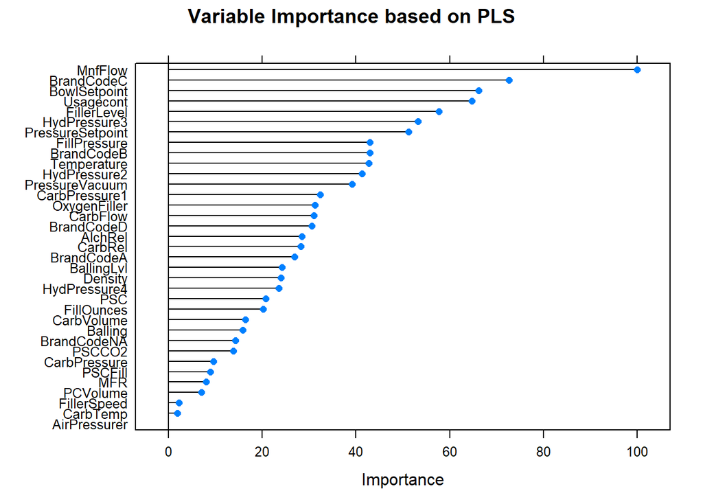

```r
plot(varImp(plsFit), main='Variable Importance based on PLS')
```

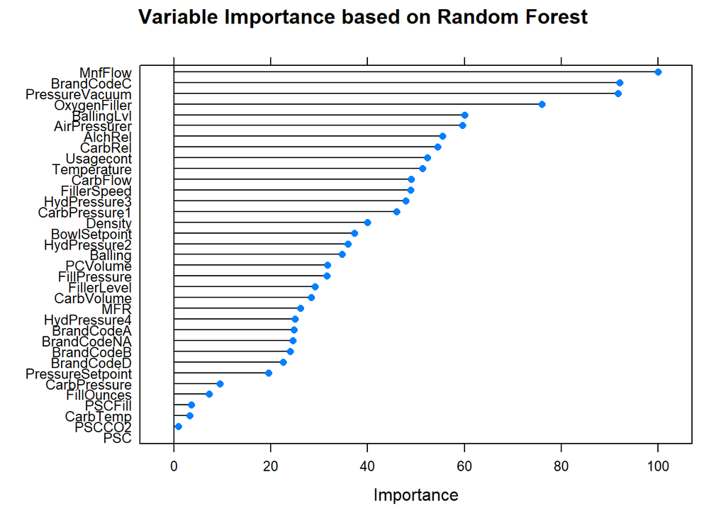

```r
plot(varImp(rf), main='Variable Importance based on Random Forest')
```

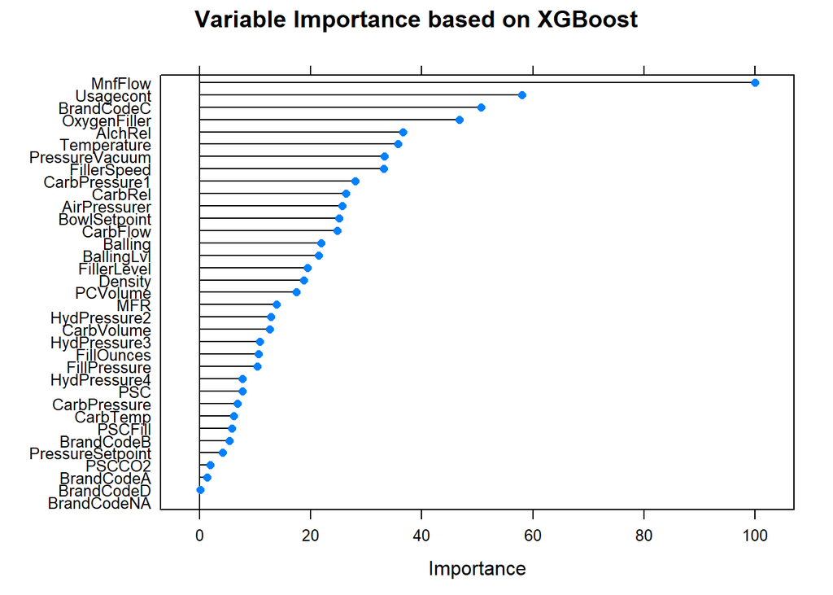

```r
plot(varImp(xgb), main='Variable Importance based on XGBoost')
```

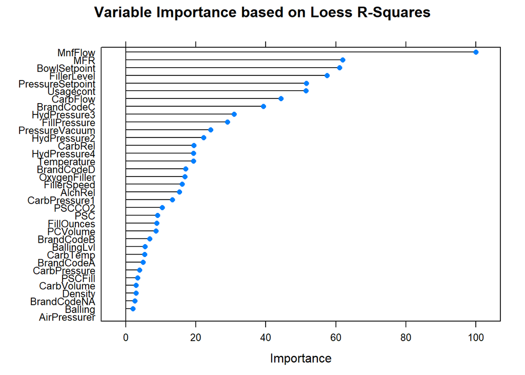

```r
plot(varImp(svmFit), main='Variable Importance based on Loess R-Squares')
```

### Model Performance

The models’ performance are listed below:

```r
resamples(list(PLS=plsFit, ENet=enetFit, KNN=knnFit, SVM=svmFit, RF=rf, XGB=xgb)) %>% summary()
```

[output not shown]

It can be seen that the XGBoost model achieves better performance. It has the lowest average RMSE. Based on this, we opt to choose the XGBoost model as our final models.

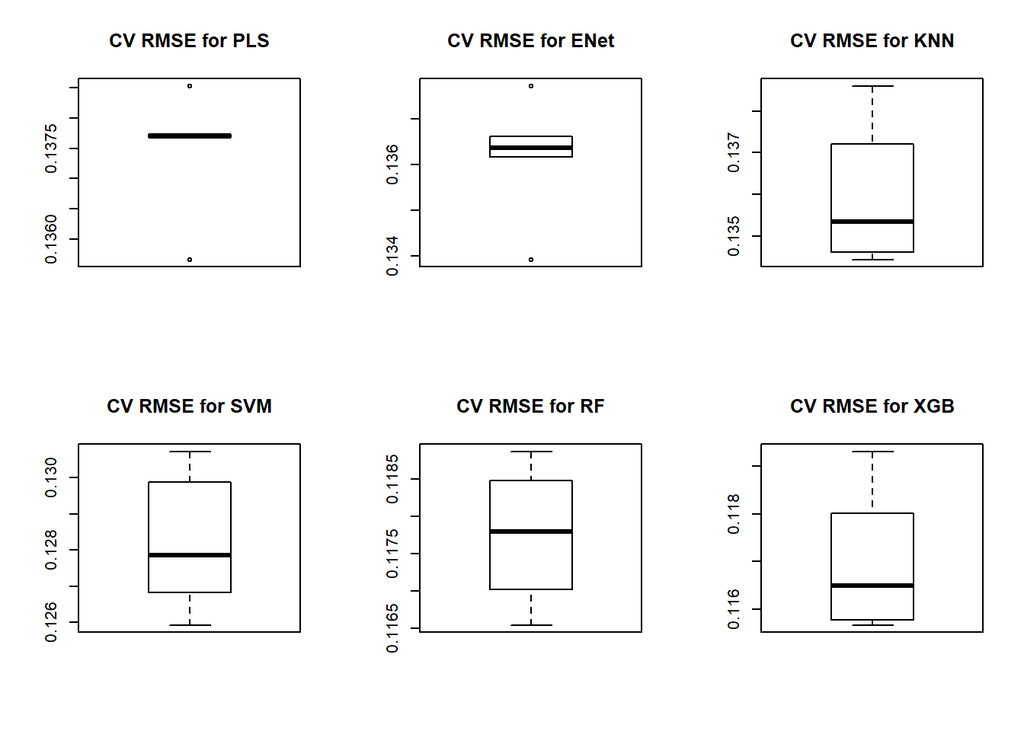

```r
par(mfrow=c(2,3))
boxplot(plsFit$resample$RMSE, main='CV RMSE for PLS')
boxplot(enetFit$resample$RMSE, main='CV RMSE for ENet')
boxplot(knnFit$resample$RMSE, main='CV RMSE for KNN')
boxplot(svmFit$resample$RMSE, main='CV RMSE for SVM')
boxplot(rf$resample$RMSE, main='CV RMSE for RF')
boxplot(xgb$resample$RMSE, main='CV RMSE for XGB')
```

### Eval Set Prediction

Below, we make the prediction using the XGB model, and save the result:

```r
(pred <- predict(xgb, newdata=xEval))
```

```
##   [1] 8.489114 8.386810 8.499494 8.676891 8.422321 8.508721 8.479796
##   [8] 8.509658 8.524522 8.733335 8.540319 8.524879 8.476252 8.604997
##  [15] 8.263277 8.584721 8.598623 8.507232 8.503490 8.716899 8.680784
##  [22] 8.667629 8.563601 8.511458 8.669805 8.493483 8.405451 8.685325
##  [29] 8.666525 8.699488 8.642038 8.702867 8.616266 8.672192 8.685741
##  [36] 8.555187 8.504755 8.530453 8.691133 8.752850 8.788443 8.525010
##  [43] 8.294233 8.275476 8.710000 8.754517 8.757333 8.724513 8.702127
##  [50] 8.766453 8.628973 8.692094 8.721963 8.720330 8.863279 8.751065
##  [57] 8.442047 8.509911 8.702737 8.782986 8.788027 8.719201 8.736992
##  [64] 8.802861 8.810700 8.704443 8.547973 8.540565 8.610917 8.506020
##  [71] 8.456654 8.384642 8.520053 8.508084 8.515755 8.496242 8.584035
##  [78] 8.662597 8.725308 8.639506 8.773076 8.661763 8.719378 8.628849
##  [85] 8.708687 8.742179 8.739834 8.647678 8.537263 8.726831 8.616635
##  [92] 8.618535 8.537017 8.510901 8.567130 8.626575 8.634910 8.625755
##  [99] 8.660060 8.676085 8.668866 8.717737 8.719065 8.701555 8.777940
```

[output cut: 24 more lines]

```r
eval$PH <- pred
write.csv(eval, "StudentEvaluation_PH_PREDICTED.csv", row.names=FALSE)
```